# EDA of FEMA earthquake risk index for SF

Philippe Marchand

2025-10-22

## Load data and packages

From the national shapefile of National Risk Index (NRI) data for all US census tracts, only keep the 241 San Francisco tracts, and the subset of columns pertaining to earthquakes (*ERQK*), the social vulnerability and resilience variables (*SOVI*, *RESL*, *CRF*) and basic identifiers like the tract ID and population.

([link to NRI data](https://hazards.fema.gov/nri/data-resources)) ([link to NRI documentation](https://www.fema.gov/sites/default/files/documents/fema_national-risk-index_technical-documentation.pdf))

```r
library(tidyverse)
library(sf)
library(cowplot)

nri <- read_sf("NRI_Shapefile_CensusTracts")
nri <- filter(nri, COUNTY == "San Francisco")
nri <- select(nri, matches("^(TRACT|POP|ERQK|SOVI|RESL|CRF)"))
```

## Risk index calculation

The description of the risk index calculation is based on the published documentation and verified with the downloaded data.

For each type of hazard (e.g. earthquake), the risk index is given as a *value*, *score* and *rating*. The risk value (RISKV) is given by multiplying an estimate of the expected annual loss (EAL, in $) from this type of hazard by a community risk factor (CRF). The CRF is a composite index grouping various socioeconomic variables related to community vulnerability and resilience, and by construction it is bounded by 0.5 and 2, so at most the CRF can half or double the risk compared to the “average” community. The CRF used is the same for all types of hazards.

$RISKV = EAL \times CRF$

The risk score (between 0 and 100) is the percentile rank of the geographical unit (here, a census tract) compared to all other units nationally, so a tract with a score of 90 is more at risk than 90% of census tracts in the US.

The risk rating is a five-point ordinal scale (Very Low, Relatively Low, Relatively Moderate, Relatively High and Very High) that is created from the risk scores by k-means clustering of the scores.

### Expected annual loss calculation

The expected annual loss is the product of three terms. It is calculated separately for agriculture, buildings and people (only buildings and people for earthquakes), then added.

$EAL = EXP \times AFREQ \times HLR$

- Exposure (EXP): The number of people or value of buildings in the census tract.
- Annualized frequency (AFREQ): The fraction of years where the hazard is projected to affect the tract.
- Historic loss ratio (HLR): The average fraction of people or buildings lost when the hazard occurs.

The EAL for buildings is a dollar value whereas the EAL for people is converted to dollars with a factor of 11.6 M$ / life.

### Community risk factor calculation

The community risk factor (CRF) is a monotonic transformation of the ratio between two indices representing vulnerability and resilience of communities.

$CRF = f(SOVI / RESL)$

The social vulnerability index (SOVI) is a CDC index ([source](https://www.atsdr.cdc.gov/place-health/php/svi/index.html)) that’s a composite of different census (ACS) variables indicating vulnerabiliy, such as: poverty, unemployment, low education, no health insurance, age 65+ or 17-, disability, single-parent households, non-English speaking, non-white populations, mobile homes, multi-unit structures, crowded housing, no vehicle. Each variable is converted to a percentile rank before averaging, so they are on a comparable scale.

The community resilience index (RESL, [source](https://sc.edu/study/colleges_schools/artsandsciences/centers_and_institutes/hvri/data_and_resources/bric/)) is a composite of variables including educational, economic, infrastructure, governance, community capacity, and natural environment. Because it’s only available at the county level, it doesn’t vary by census tract within San Francisco.

The monotonic function $f$ in the equation above takes the percentiles of SOVI/RESL and converts them to quantiles of a triangular distribution with minimum at 0.5, maximum at 2 and mode at 1.

## Earthquake risk index components for San Francisco

### Annualized frequency

The annualized earthquake frequency is just under 0.01 (1 in 100 years) for the vast majority of tracts, with slightly higher values (up to 0.02) in some coastal areas and surprisingly high values for the Presidio (0.04) and one coastal tract near Lands End (0.06).

```r
summary(nri$ERQK_AFREQ)
```

```
##     Min.  1st Qu.   Median     Mean  3rd Qu.     Max.
## 0.008901 0.009060 0.009099 0.009949 0.009210 0.063797
```

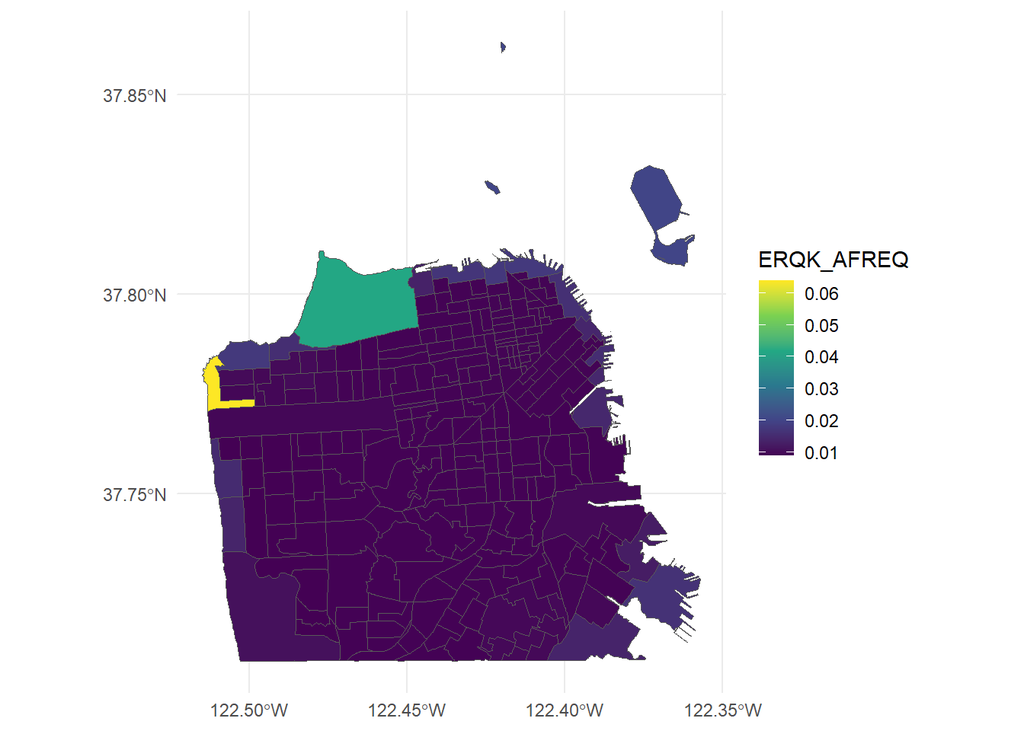

```r
ggplot(nri, aes(fill = ERQK_AFREQ)) +
    geom_sf() +
    scale_fill_viridis_c() +
    theme_minimal()
```

### Expected damage to people

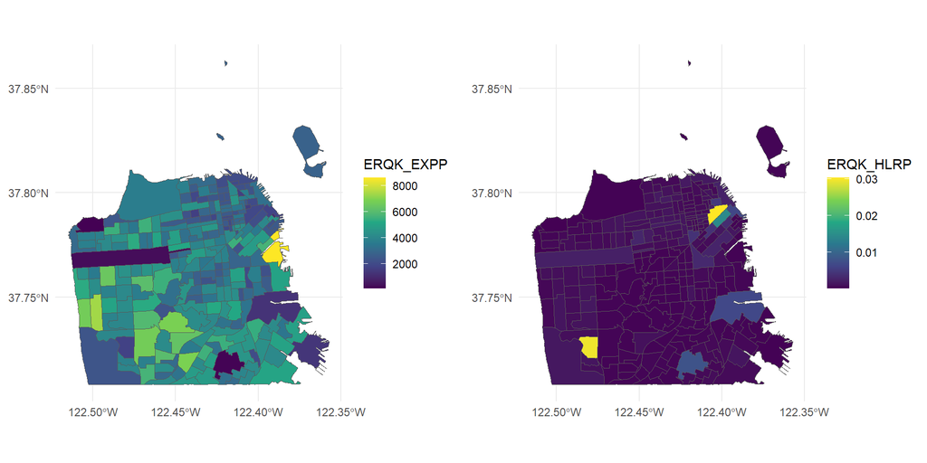

```r
p1 <- ggplot(nri, aes(fill = ERQK_EXPP)) +
    geom_sf() +
    scale_fill_viridis_c() +
    theme_minimal()

p2 <- ggplot(nri, aes(fill = ERQK_HLRP)) +
    geom_sf() +
    scale_fill_viridis_c() +
    theme_minimal()

plot_grid(p1, p2)
```

```r
summary(nri$ERQK_HLRP)
```

```
##      Min.   1st Qu.    Median      Mean   3rd Qu.      Max.
## 4.357e-05 3.137e-04 6.023e-04 1.134e-03 9.635e-04 3.035e-02
```

```r
select(nri, TRACT, POPULATION, ERQK_HLRP) %>%
    st_drop_geometry() %>%
    arrange(desc(ERQK_HLRP)) %>%
    head(10)
```

```
## # A tibble: 10 × 3
##    TRACT  POPULATION ERQK_HLRP
##    <chr>       <dbl>     <dbl>
##  1 011700       1905   0.0303
##  2 033201       1729   0.0296
##  3 061501       2106   0.0144
##  4 980501        125   0.00784
##  5 980900       1248   0.00655
##  6 061507       1738   0.00641
##  7 061101       2008   0.00492
##  8 012405       4127   0.00415
##  9 017602       3649   0.00414
## 10 061503       4039   0.00354
```

The two tracts with the highest loss ratio are 011700 (Financial District / Union Square) and 033201 (Stonestown / SFSU). 061501 is in SOMA across Market St. from the financial district, 980501 is McLaren Park in southeast SF, 980900 is the industrial area around Islais Creek between Dogpatch and Bayview. It’s not clear why some of those areas are singled out for the potential damage to people.

In any case, the overall EAL for people reflects the same outliers as the HLR variable, though also tracts with higher population.

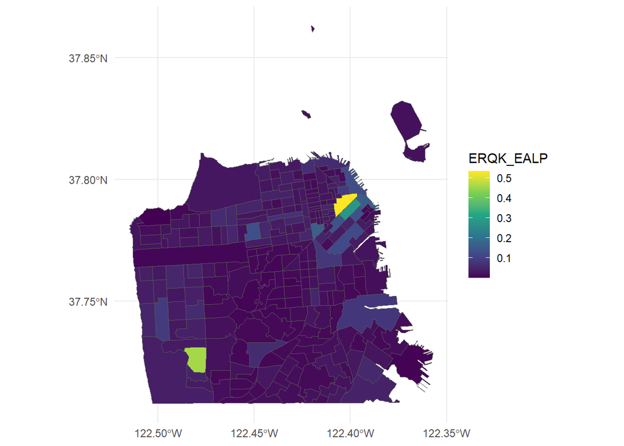

```r
ggplot(nri, aes(fill = ERQK_EALP)) +
    geom_sf() +
    scale_fill_viridis_c() +
    theme_minimal()
```

### Expected damage to buildings

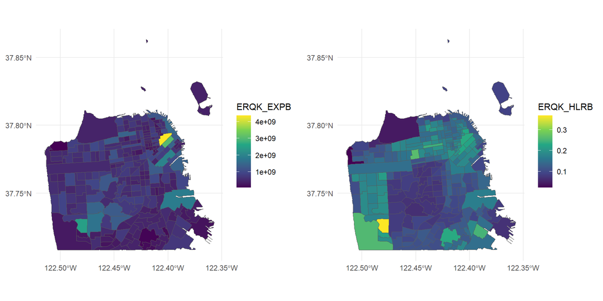

```r
p1 <- ggplot(nri, aes(fill = ERQK_EXPB)) +
    geom_sf() +
    scale_fill_viridis_c() +
    theme_minimal()

p2 <- ggplot(nri, aes(fill = ERQK_HLRB)) +
    geom_sf() +
    scale_fill_viridis_c() +
    theme_minimal()

plot_grid(p1, p2)
```

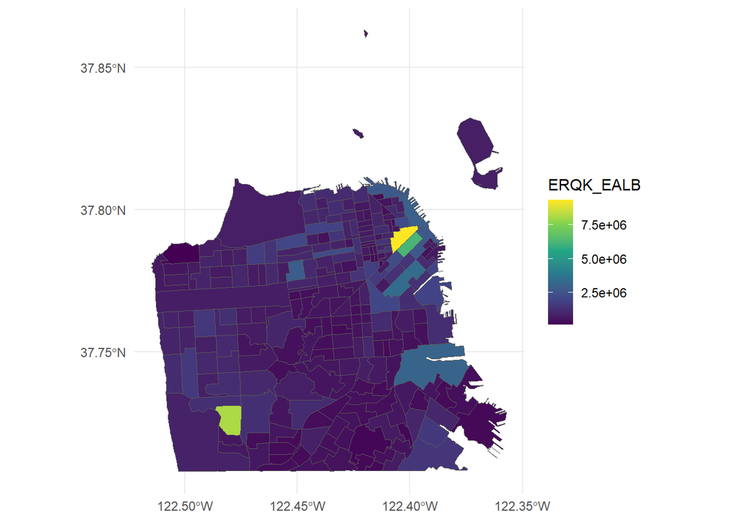

```r
ggplot(nri, aes(fill = ERQK_EALB)) +
    geom_sf() +
    scale_fill_viridis_c() +
    theme_minimal()
```

### Combined expected damage to people and buildings

For most tracts, the expected annual loss to buildings is valued at several times the expected loss to people when converted into dollars (with the value of 11.6 M$ per life). Note that the extreme ratio of 141 in the summary is for a tract (Lincoln Park) where almost no one lives.

```r
summary(nri$ERQK_EALB / nri$ERQK_EALPE)
```

```
##     Min.  1st Qu.   Median     Mean  3rd Qu.     Max.
##   0.6259   2.2853   2.9214   3.8415   3.7905 141.4776
```

Nevertheless, because the areas with higher risk to people and to buildings were similar in the previous sections, the same areas stand out for the total EAL.

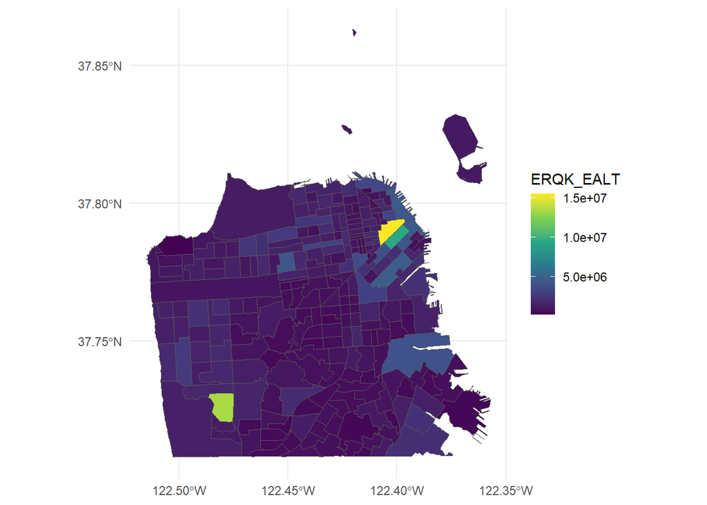

```r
ggplot(nri, aes(fill = ERQK_EALT)) +
    geom_sf() +
    scale_fill_viridis_c() +
    theme_minimal()
```

### Community risk factor

Because one of the two components of the CRF (the resilience index) is only calculated by county, the map of the CRF below directly reflects differences in the social vulnerability index, which again mostly represents differences in socioeconomic status across the city.

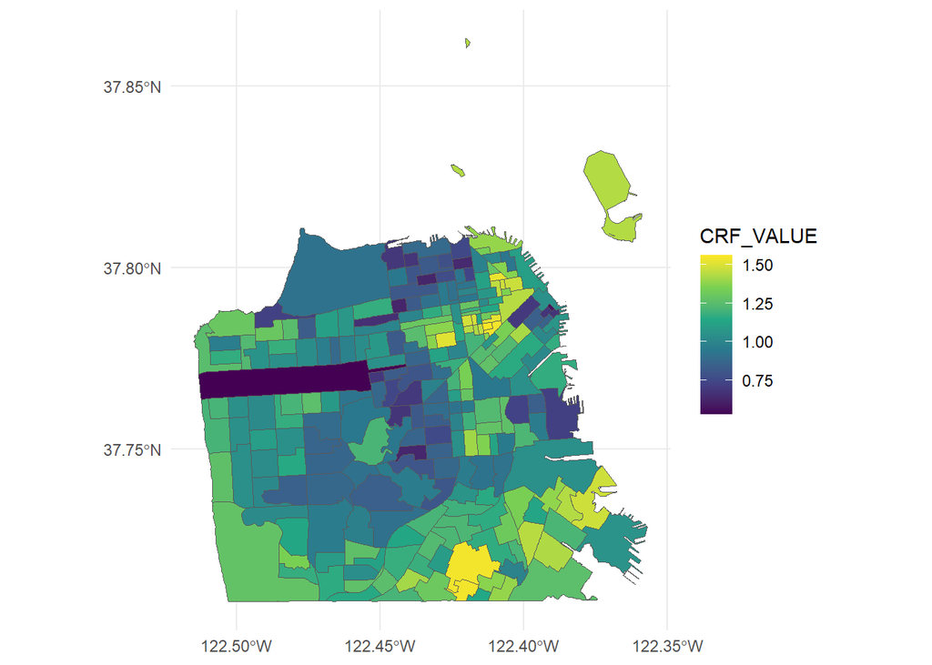

```r
ggplot(nri, aes(fill = CRF_VALUE)) +
    geom_sf() +
    scale_fill_viridis_c() +
    theme_minimal()
```

### Risk index score and rating

The overall earthquake risk score (left) and rating (right) are shown in the map below. Note that the outliers from the EAL data above are less apparent due to the conversion of the risk value to a percentile score. As SF is more at risk of earthquakes than most of the country, almost all percentiles are above 80. (Indeed, if we removed parks from the dataset, it would remove the only value under 80 and the only “Relatively Low” value, which is in Lincoln Park.)

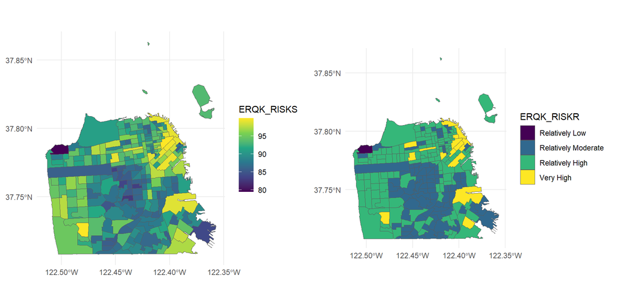

```r
nri$ERQK_RISKR <- factor(nri$ERQK_RISKR,
                         levels = c("Relatively Low", "Relatively Moderate",
                                    "Relatively High", "Very High"))

p1 <- ggplot(nri, aes(fill = ERQK_RISKS)) +
    geom_sf() +
    scale_fill_viridis_c() +
    theme_minimal()

p2 <- ggplot(nri, aes(fill = ERQK_RISKR)) +
    geom_sf() +
    scale_fill_viridis_d() +
    theme_minimal()

plot_grid(p1, p2)
```

## Commentary

I think the risk rating map from the previous section would be usable, with only 3 colored categories of risk (moderate, high and very high) to avoid adding too much complexity to the user-facing map.

My main concerns from looking at the detailed data were (1) that the risk score is based on aggregate expected damages to people and buildings, thus putting more weight on census tracts with more people and more (or higher-valued?) buildings; and (2) the presence of outliers (like the Stonestown/SFSU tract).

Concern (2) is mitigated by the percentile transform reducing the impact of outliers on the overall visualization. As for concern (1), although in some case the historic loss ratio component might be a better indicator for people thinking of their individual risk (rather than the aggregate risk to everyone in a tract), the areas with high loss ratio to people and buildings seem to be well-reflected in the final risk map as well.

I would suggest perhaps to still consult with some local earthquake experts to make sure the map makes sense, since a nationally-produced map, even if it provides data at the tract level, may not always reflect local particularities.